# Logboek Ivar Jaar 2 P1

### multiqc resultaten

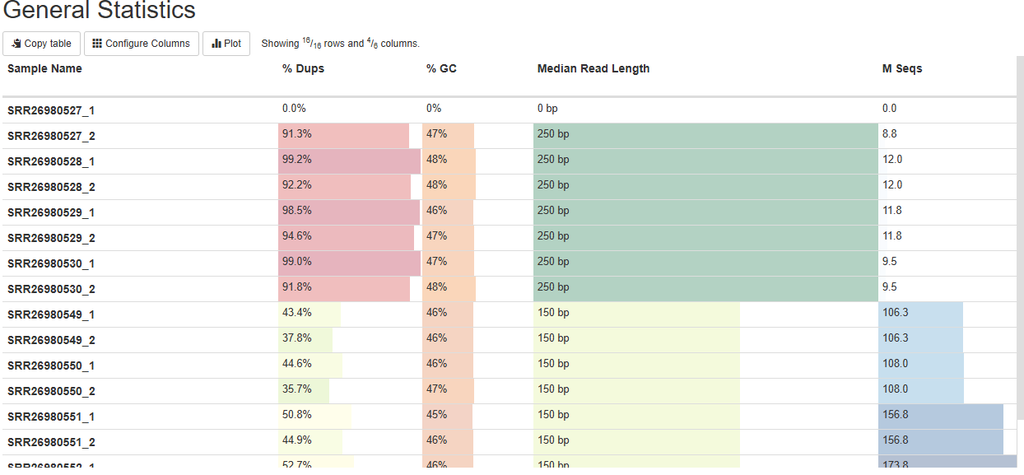

Uit de general statistics plot kan ik halen dat de download van de eerste sample mislukt is. Ook bevatten de eerste 4 samples en hun reverse componenten ruim 90% duplicaten wat dramatisch slecht is.

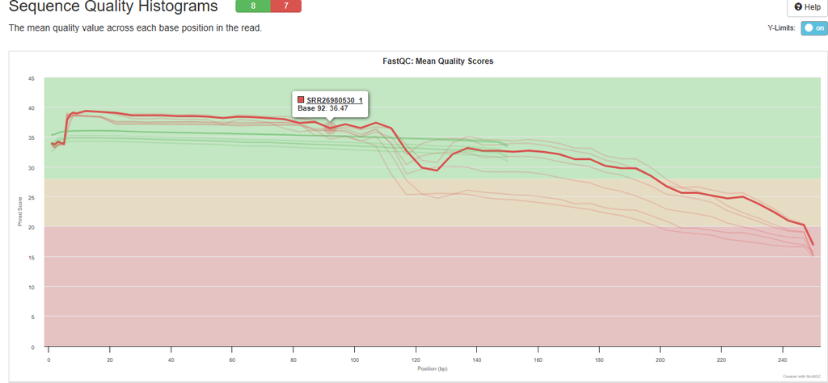

De kwaliteit per base plot laat zien dat de samples met de 90% duplicates ook van best slechte kwaliteit zijn. ook is het biezonder dat de gehighlighte sample een sprong in kwaliteit maakt. de normale verwachting is dat de lijn in de kwaliteit een soort banaan vorm heeft. de samples die minder dan 90% duplicates hebben lijken van voldoende kwaliteit.

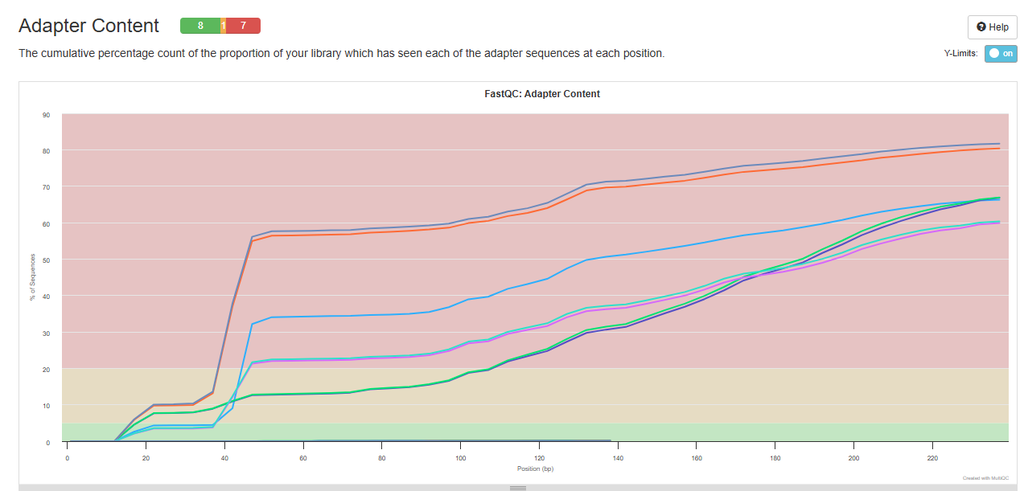

De 90% duplicatie samples hebben ook dramatisch hoge adaptercontent score. dit zou mogelijk een verklaring kunnen zijn van de hoeveelheid duplicaties.

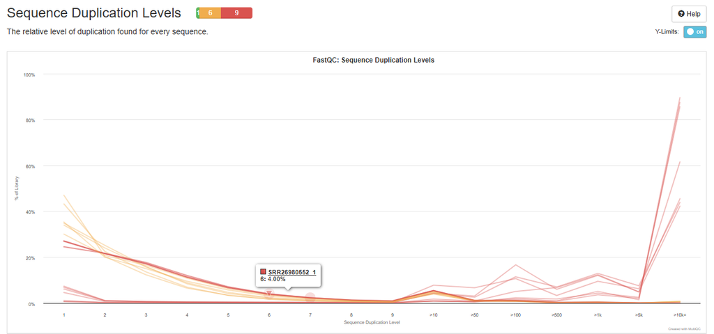

Dit plot visualiseert de hoeveelheid duplicatie per sequentie. van de eerste 4 samples had ik verwacht dat de piek in duplicaten hoger zou zijn aan het begin vanwege de hoeveelheid adapters. dit zou kunnen hinten naar pcr artefacten.

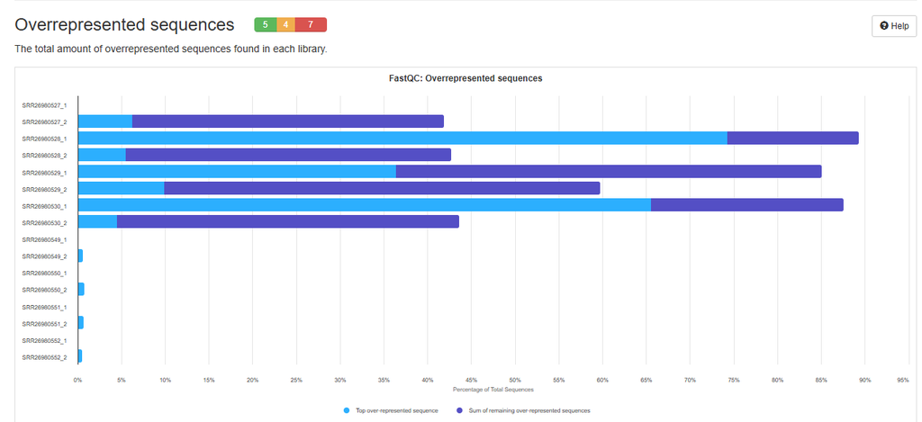

overrepresentive

Hieruit kun je zien dat de sample’s 527,528,529,530 van zeer slechte kwaliteit zijn. Het meest bijzondere aan deze samples is de absurde hoeveelheid duplicaten hierin. Bij de individuele fastqc rapporten van de bovenstaande 4 samples heb ik gekeken naar de overrepresented sequences. In deze lijst stonden een paar sequenties die herkent werden als adapters maar de meesten niet. Ik heb 1 van de sequentie op advies van Ronald geblast. BLAST is een alignment tool van NCBI en het doel van dit programma is het vergelijkingen van de opgegeven sequentie met de referentie database om te kijken wat opgegeven sequentie is en waarvoor hij misschien zou kunnen zijn.

Ik heb 1 van de sequentie’s die voor 60% verantwoordelijk was voor de duplicatie door 4 blast databasen gehaald en hieruit kwam bij alle 4 geen match.

### Uitkomst Eerste FastQC

Dit alles bij elkaar vindt ik dat we de eerste 4 samples waarschijnlijk niet bruikbaar zijn voor verder onderzoek vanwege hun slechte kwaliteit. de laatste 4 lijken wel van goed genoege kwaliteit te zijn om te gebruiken. Deze samples scoren goed in de algemene kwaliteit plotten na het trimmen moet er nog wel gekeken worden naar de duplicatie plots om te kijken of daar nog eventuele problemen in kunnen zitten

#### Blast settings

Core nucleotide database Nucleotide collections refseq genome databse (Mus Muscus) refseq Reference genomes (Mus Muscus)

### Resultaten

FastQC + Multiqc analyse gedaan, bestanden staan in /students/2024-2025/Thema05/3dconformatieChromatine/fastqc_output/

## Woensdag

Het doel van vandaag is samen met storm en Jarno aan het automatische bwa-mem commando werken.

### mapping bijproduct

Om uit te vinden van wat de 4 eerste samples zijn hadden wij het idee om het sample te mappen tegen een referentie genoom om te kijken wat deze samples zouden kunnen zijn. uiteindelijk hebben wij hier niks mee gedaan vanwege de slechte kwaliteit van deze samples. Dit wordt later in het logboek uitgelegd. Gezamenlijk zijn wij bezig geweest met het BWA-MEM commando en hebben dit ook gerunt. maar vervolgens hebben wij hier niks me gedaan. de uitleg hiervoor komt later in het bestand.

## Vrijdag

Vandaag is het doel om samen met storm het trimmomatic commando af te maken zodat we daar mee kunnen experimenteren voor onze data analyse.

### Trimmomatic settings

minlen 40 standaard, verwijdert alle reads weg met een lengte van onder de 40

slidingwindow 4 : 20 standaard verwijdert alle sequenties als de gemmiddelde kwaliteit per 4 sequenties onder de 20 komt.

Ilumina clip: /pad/TruSeq3 Voor het verwijderen van adapters hiervoor hebben we de door trimmomatic meegeven TruSeq3 adapters gebruikt omdat de dit standaard adapters zijn door HiSeq en MiSeq sequencer aparaten. In ons geval is de nieuwe NovaSeq 6000 gebruikt. Zoals het lijkt zijn de standaard adapters hiervoor niet veranderd. (https://www.researchgate.net/post/Have_Illumina_adapter_sequences_changed_for_NovaSeq_6000)

threads -80 hoeveelheid instructies die gestuurd kunnen worden naar de CPU’s.

Met de samples in accesion list word hier de trimmomatic parralel op uitgevoerd. voor de input en uitput bestanden word het hele pad gebruikt met een {} op de plek van de sample namen voor de samples. dit word aangevult met _nummer1/2.fastq voor forward en reverse reads bij de input bestanden en _outputnaam en type voor de output bestanden.

De input en uitput bestanden zijn bijde van het type .fastq

Trimmomatic command het orginele commando bestaad uit: TrimmomaticPE voor paired end, threads voor hoeveelheid opdrachten die je aan de cpu/server megeeft, input bestand forward(.fastq), input bestand reverse(.fastq), paired output_1(.fastq) , unpaired output_1, paired output_2, unpaired output_2, opties

```bash
# parralel runnen op de SraAcc list zodat er maar 1 run is per sample en deze gepaard blijven
# doormiddel van {}_1 en {}_2
cat /students/2024-2025/Thema05/3dconformatieChromatine/SRA/SraAccList.csv | \
  parallel 'TrimmomaticPE -threads 80 ' \
                  '/students/2024-2025/Thema05/3dconformatieChromatine/fastq/{}_1.fastq ' \
                  '/students/2024-2025/Thema05/3dconformatieChromatine/fastq/{}_2.fastq ' \
                  '/students/2024-2025/Thema05/3dconformatieChromatine/Trimmomatic_output/paired/{}_forward_paired.fastq ' \
                  '/students/2024-2025/Thema05/3dconformatieChromatine/Trimmomatic_output/unpaired/{}_forward_unpaired.fastq ' \
                  '/students/2024-2025/Thema05/3dconformatieChromatine/Trimmomatic_output/paired/{}_rev_paired.fastq ' \
                  '/students/2024-2025/Thema05/3dconformatieChromatine/Trimmomatic_output/unpaired/{}_rev_unpaired.fastq ' \
                  'ILLUMINACLIP:/students/2024-2025/Thema05/3dconformatieChromatine/Trimmomatic/Trimmomatic-0.39/adapters/TruSeq3-SE.fa:2:30:10 ' \
                  'MINLEN:40 ' \
                  'SLIDINGWINDOW:4:20'
                  'HEADCROP:10'
```

### Resultaten

Functioneel bash script voor trimmen

# Week 3 Eindresultaat quality control en bwa mapping en varriant calling

## Maandag

Het doel vandaag is besluiten wat we doen met de samples van dramatisch slechte kwaliteit en met trimmomatic experimenteren. Dit doen we om de data klaar te zetten voor het mappen en alignen.

### Besluit samples

Als groep hebben we besloten om de samples 527,528,529,530 te verwijderen uit verdere pipeline vanwege slechte kwaliteit score op het fastqc rapport en we hebben het sample type wildtipe niet per se nodig voor ons genetisch onderzoek.

### Trimmomatic en FastQC

Trimmomatic 2 pogingen met en zonder de optie headcrop + fastqc en multiqc voor controle van de getrimde data. verdere opties: minlen 40 zo als beschreven in het vorige trimmomatic commando

slidingwindow 4:20 zo als beschreven in het vorige trimmomatic commando

Iluminaclip Truseq3 zo als beschreven in het vorige trimmomatic commando

Headcrop: 10 Het idee hierachter was de eerste 10 bases te verwijderen in het geval er nog veel over-gerepresenteerde sequences waren en bij de samples die later vandaag verwijderd zijn. aangezien een aantal van deze sequences op adapters leken en of in elk geval heel erg op elkaar leken dachten we dat het verwijderen van de eerste 10 bases met een potentieële adapter en identificator sequentie te verwijderen om de samples mogenlijk bruikbaar te maken.

circa 95% van de reads per sample overleven het als gepaarde read. In de trimmomatic output stond dat het headcrop argument was gefaald en niet is meegenomen in het trimmen. Dit beinvloed ons verder niet omdat we de samples waarvoor we de headcrop wouden gebruiken verwijderd zijn.

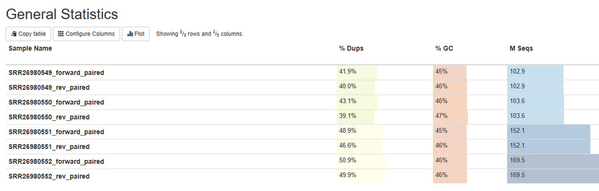

Bij de standaard statistieken zie ik dat de CG percentages iets uit elkaar liggen mijn eerste gedachte hierbij was dat de samples misschien gecontamineerd is maar volgens Ronald is het normaal dat CG% 1% of 2% uit elkaar kunnen liggen aan de hand van het type cell dus dit hoeft geen probleem te zijn. Het gemmiddelde CG percentage van een muis is 42% (GRCm39 reffrence genome. https://www.ncbi.nlm.nih.gov/datasets/genome/GCF_000001635.27/). Het chromosome met het hoogste CG% is 44% op chromosome 11. Dit is ook het chromosome waar het Ebf1 gen op ligt dat gebruikt is in het onderzoek. (https://www.ncbi.nlm.nih.gov/gene/13591) Onze samples hebben een gemiddelde CG percentage van 45,75 deze informatie bevestigt ons idee dat dit onderzoek geen whole genome sequencing heeft gedaan maar een selectie heeft gemaakt en dit waarschijnlijk heeft geampliceerd met de aaname dat dit choromosme 11 is met de reden dat hier het Ebf1 gen op ligt dat critiek is bij dit onderzoek. De hoeveelheid duplicaties kan hiermee deels verklaart worden.

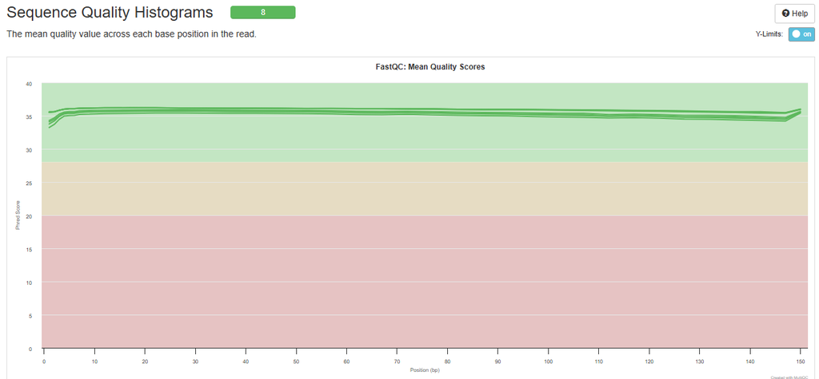

Zoals hier te zien is de gemiddelde kwaliteit van deze samples wel goed het piek omhoog aan het eind is resultaat van het trimmen.

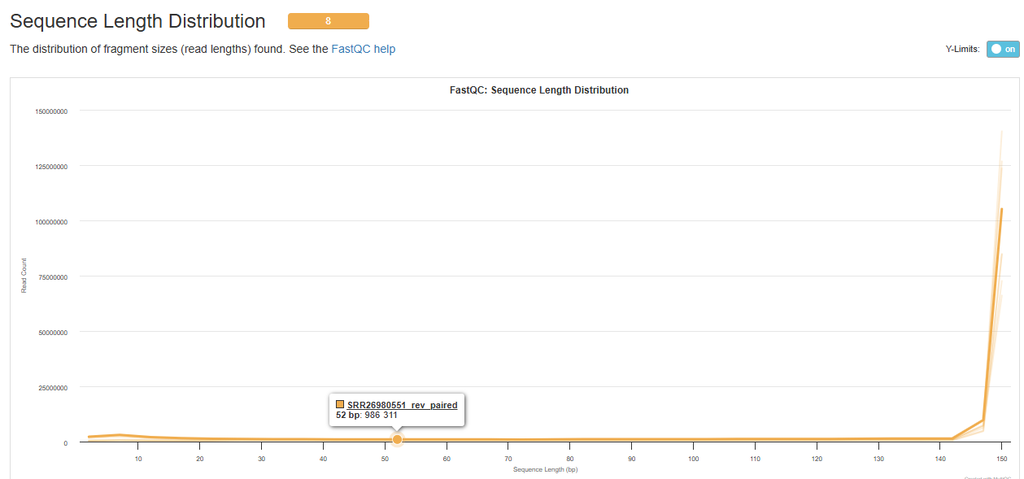

Het opvallende hier is dat er een piek aan het begin bij circa 10 readlengt. dit hoort niet te kunnen aangezien hij alle reads onder 40 in lengte door trimmomatic had moeten verwijderen. Trimmomatic had ook geen error aangegeven dat het minlen argument was gefaald of niet gevonden was.

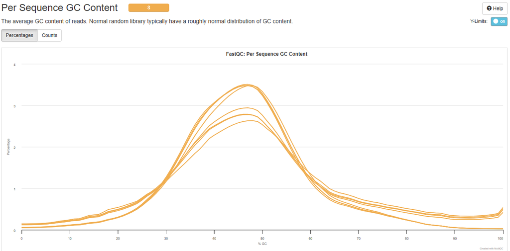

Het CG plot geeft een waarschuwing aan omdat het cg percentage een beetje afwijkt van een normaal verdeling heeft. Aangezien er geen scherpe pieken zijn in deze grafiek betekent het dat de samples in elk geval niet gecontamineerd zijn. Voor het trimmen gaven deze samples ook al een waarschuwing van fastqc vanwege de afwijking in deviatie. Zoals ik bij de de standaard statistiek plot heb uitgezocht ben ik van mening dat ook al is de grafiek niet netjes denk ik dat het niet een significant probleem is voor ons verdere onderzoek. De 2 verschillende hoogtes zal waarschijnlijk te maken hebben met het feit dat zoals te zien bij standaard statistieken dat er verschillende hoeveelheden sequentie gemeten zijn en dat er tussen 549/550 100 miljoen sequentie’s gemeten zijn en bij 551/552 150 miljoen sequenties zijn gemeten.

Overrepresented sequences Hier is geen plot voor maar het gaf een waarschuwing aan bij de 4 reverse paired reads. hier zal ik morgen naar kijken en eventueel met ronald overleggen omdat ik het raar vind dat dit alleen voorkomt bij de reverse paired reads.

Adapter content hier is ook geen plot meer voor omdat er geen adapters meer gevonden zijn.

## Dinsdag

Het doel van vandaag is overleggen met Ronald over onze onderzoeksvraag en commentaar op de fastqc data.

### Commentaar Fastqc

multiqc overrepresentive sequences. Na het bekijken van de individuele fastqc bestanden blijkt dat alle reverse read samples een overrepresentatie hebben van een verlengde GGGGGGG van varieërende lengtes. Volgens Ronald kan dit een echt stuk genoom zijn of pcr artifact. Ik heb 1 van de sequences geblast via (https://blast.ncbi.nlm.nih.gov/Blast.cgi) door de volgende databases (Mus Muscus): Core nucleotide database. Nucleotide collections. Bij beide databases was er geen match en een globale google search om te kijken of er een lange ggg repeat sequentie in het genoom van een muis zit leverde ook geen informatie op. Dit samen met het feit dat dit deze sequentie alleen wordt aangegeven op de reverse pair reads concludeer ik dat dit hoogstwaarschijnlijk een mechanische fout heeft plaats gevonden tijdens het sequencen.

### Conclussie FastQC

De conclusie van de fastqc rapport is dat de samples 549, 550, 551, 551 goed zijn op het gebied van de algemene sequentie kwaliteit. Alleen deze samples laten een aantal bijzonderheden zien die we niet helemaal kunnen verklaren, maar hoogstwaarschijnlijk niet ernstig genoeg zijn om de verdere stappen te kunnen beïnvloeden.

### Onderzoeksvraag

Als groep hadden wij tot vandaag nog geen onderzoeksvraag. Na overleg met Ronald zijn wij op het volgende gekomen. “Zijn er genetische varianten te vinden in het embf1 en pax5 gen te vinden dat het vorige onderzoek kan beinvloeden” die in het genoom van rag2(-/-) muizen

### BWA mapping

Voor een voledige uitleg van bwa-mem2 mappen zie het logboek van Jarno en Floris. Voor het Mappen gebruiken wij BWA-mem2[6]. We hebben voor deze tool gekozen omdat het volgens de mensen achter bwa de volgende versie is en een stuk efficiënter dan de standaard bwa mapper. Ook word bij het BIN galaxy systeem van de Hanze Bio-informatica systeem aangeraden om bij het mappen van reads langer dan 100 basisparen bwa-mem2 te gebruiken. Dit is toepasbaar op onze data omdat wij een gemmidelde readlengte van circa 150 hebben, zie read lengt distributie plot van de fastqc analyse.

#### Mapping en Aligment uitleg

Mappen is het proces van alle reads tegen een referentie genoom aan te leggen zodat je weet welke read op welke plek in het genoom hoort. Dit word gedaan zodat je alle reads op de plekken liggen waar ze horen en je hierna een analyse op kunt doen om te kijken of er varianten in de genen liggen. meer hierover bij variant calling. De overlappende reads op 1 plek in het genoom wordt ook wel de covarage van een gen of positie genoemd.

#### BWA-mem2

Het eerste commando in dit code blok is voor het indexeren van het referentie genoom hiervoor hebben wij het mm39 GCF genoom gebruikt (https://www.ncbi.nlm.nih.gov/datasets/genome/GCF_000001635.27/) omdat errors voorkomt bij de snipeff anotatie later vanwege de chromosoom namen.

Met het parralel word er over de accesion list heen geloopt en het volgende commando gerunt [pad bwmem2/bwa-mem2 mem] [-t 50[threads optie]] [referentie_bestand] [{}_forward bestand] [{}_reverse bestand] [>] [{}.sam] (& optioneel voor het commando om op de achtergrond te runnen)

Hieruit komt een .sam bestand dat bestaad uit een header sectie en een alignment sectie, de aligment sectie is een tabel met informatie over de alignemt. (https://en.wikipedia.org/wiki/SAM_(file_format))

```bash
# Het indexeren van het referentiegenoom met bwa-mem2.
/students/2024-2025/Thema05/3dconformatieChromatine/bwa_mem2/bwa-mem2-2.2.1_x64-linux/bwa-mem2 index -p GCF_ref /students/2024-2025/Thema05/3dconformatieChromatine/Mapping_ref/ncbi_dataset/ncbi_dataset/data/GCF_000001635.27/GCF_000001635.27_GRCm39_genomic.fna

# Voorbeeld aligning:
bwa-mem2 mem ref.fa read1.fq read2.fq > aln-pe.sam

# Align sample SRR26980549_1.fastq (deel 1 en 2) met het referentiegenoom mm39 muis.
./bwa_mem2/bwa-mem2-2.2.1_x64-linux/bwa-mem2 mem -t 50 GCF_ref fastq/SRR26980549_1.fastq fastq/SRR26980549_2.fastq > aligned_SRR26980549.sam &

# Test met parallel:
#cat /students/2024-2025/Thema05/3dconformatieChromatine/SRA/SraAccList.csv | parallel #'bwa_mem2/bwa-mem2-2.2.1_x64-linux/bwa-mem2 mem -t 50 GCF_ref fastq/{}_1.fastq #fastq/{}_2.fastq > BWA_aligned_output/aligned_{}.sam' &

# Parallel met volledig pad naar alle bestanden:
cat /students/2024-2025/Thema05/3dconformatieChromatine/SRA/SraAccList.csv | parallel '/students/2024-2025/Thema05/3dconformatieChromatine/bwa_mem2/bwa-mem2-2.2.1_x64-linux/bwa-mem2 mem -t 50 GCF_ref /students/2024-2025/Thema05/3dconformatieChromatine/Trimmomatic_output/paired/{}_forward_paired.fastq /students/2024-2025/Thema05/3dconformatieChromatine/Trimmomatic_output/paired/{}_rev_paired.fastq > /students/2024-2025/Thema05/3dconformatieChromatine/mapping/{}.sam' &
```

##### Samtools

Samtools[8] is een tool dat gebruikt word voor het aanpassen van .sam bestanden zoals sorteren en converteren naar een ander bestands type. Wij gebruiken deze tool als voorbereiding op de varriant calling hierna.

###### Herhalende argumenten

De @ en -treads zijn treads argumented die herhaald worden in de samtools code blokken. Ook word er gewerkt vanuit een parralel functie met de accesion list zoals hierboven ook gedaan word.

##### Converteren sam naar bam

De code hieronder sorteert de samfile en converteerd deze naar het type .bam bestand. .bam is hetzelfde soort bestandstype als .sam alleen dan binair gecomprimeerd. met het argument -n word het op readnaam gesorteerd.

```bash
# Voor een enkel sample:
samtools sort -@40 -n -O BAM -o aligned_sorted_SRR26980549.bam aligned_SRR26980549.sam

# Met parallel:
cat /students/2024-2025/Thema05/3dconformatieChromatine/SRA/SraAccList.csv | parallel 'samtools sort -@40 -n -O BAM -o samtools_output/aligned_sorted_{}.bam BWA_aligned_output/aligned_{}.sam ' &
```

##### Fixmate markeringen

De code hieronder voegt een markering score toe aan de reads. dit is nodig omdat we met paired end sequencing werken en de forward en reverse reads niet altijd gepaard zijn of het gepaarde read niet aan de kwaliteits eisen voldoet. Dit is nodig voor de markduplicates later.

```bash
# Voor een enkel sample:
samtools fixmate -m --threads 40 aligned_sorted_SRR26980549.bam \ fixed_mates_aligned_sorted_SRR26980549.bam

# Met parallel:
cat /students/2024-2025/Thema05/3dconformatieChromatine/SRA/SraAccList.csv | parallel 'samtools fixmate -m --threads 40 samtools_output/aligned_sorted_{}.bam samtools_output/fixed_mates_aligned_sorted_{}.bam' &
```

##### 2de sortering

In de code hieronder word het bestand nogmaal gesorteed ditmaal op coördinaten dit is nodig voor de mark duplicates.

```bash
# Voor een enkel sample:
samtools sort -@80 -o sorted_coordinates_SRR26980549.bam \ fixed_mates_aligned_sorted_SRR26980549.bam

# Met parallel:
cat /students/2024-2025/Thema05/3dconformatieChromatine/SRA/SraAccList.csv | parallel 'samtools sort -@80 -o samtools_output/sorted_coordinates_{}.bam samtools_output/fixed_mates_aligned_sorted_{}.bam' &
```

##### Markduplicates

In de code hieronder worden de duplicaten gemarkeerd en verwijdert. -r argument is voor het verwijderen van de duplicaten -s argument is voor het maken van een statistiek rapport over de markduplicates acties

```bash
# Voor een enkel sample:
samtools markdup -r -s sorted_coordinates_SRR26980549.bam dedup_SRR26980549.bam

# Met parallel:
cat /students/2024-2025/Thema05/3dconformatieChromatine/SRA/SraAccList.csv | parallel  'samtools markdup -@80 -r -s samtools_output/sorted_coordinates_{}.bam samtools_output/dedup_{}.bam' &
```

##### Indexering

Met de code hieronder word een index .bai bestand gemaakt.

```bash
# Voor een enkel sample:
samtools index -@80 dedup_SRR26980549.bam dedup_SRR26980549.bai  &

# Met parallel:
cat /students/2024-2025/Thema05/3dconformatieChromatine/SRA/SraAccList.csv | parallel 'samtools index -@80 samtools_output/dedup_{}.bam samtools_output/dedup_{}.bai' &
```

### Freebayes variant calling

Voor een voledige uitleg van Freebayes[7] variant calling zie het logboek van Jarno en Floris.

#### Freebayes tool

Wij hebben voor Freebayes gekozen omdat dit een snellere en minder complexe variant calling tool is dan GATK, GATK werd ook afgeraden door de docenten vanwege de complexiteit en documentatie van deze tool. Freebayes heeft in vergelijking tot andere varscan en lofraq een hogere kans op het vinden van varianten maar ook een hogere kans op vals positieven. (https://pmc.ncbi.nlm.nih.gov/articles/PMC6234735/)

#### Variant calling uitleg

Variant calling is het proces van het vinden van varianten op een positie in het genoom op basis van de hoeveelheid reads en de referentie positie.

De exacte parameters van Freebayes staat niet in hun handleiding maar uit de lessen van Bio-informatica Thema5(https://rwedema.github.io/NGS-Genetics/mapping.html) kan ik er van uit gaan dat een variant minstens een covarige van 20 reads nodig heeft om geclassificeerd te worden als variant. Onder 20 reads is het namelijk lastig om het statistisch te verantwoorden dat het een variant is of een technische fout.

#### Variant anotatie uitleg

Variant annotatie is de actie van metadata en effect voorspellingen aan de gevonden varianten toe te voegen. Dit word gedaan doormiddel van de varianten door een database te halen bij elke variant informatie toe te voegen aan het bestand.

#### SNPeff

Wij hebben voor snpeff gekozen vanwege de hoeveelheid genomen die deze database heeft. Ook zijn de resultaten gelijkwaardig aan andere annotatie tools, al word het door andere tools anders beschreven.(https://pubmed.ncbi.nlm.nih.gov/28122645/)

#### Floris zijn code

##### Indexering referentie genoom

hieronder word het referentie genoom ge indexeert.

```bash
samtools faidx GCA_000001635.9_GRCm39_genomic.fna
```

in de 2 code blokken hieronder freebayes -> referentie database -> inputfile.bam -> outputfile.vcf

```bash
# Test voor een enkel .bam bestand:
/students/2024-2025/Thema05/3dconformatieChromatine/freebayes/freebayes-1.3.6-linux-amd64-static -f GCA_000001635.9_GRCm39_genomic.fna \ /students/2024-2025/Thema05/3dconformatieChromatine/aligned_sorted_SRR26980549.bam > \ /students/2024-2025/Thema05/3dconformatieChromatine/variant_calling/SRR26980549_test.vcf
```

–minQualScore 30 minimale kwaliteit score argument –outputvcf output argument

```bash
# parralel
cat /students/2024-2025/Thema05/3dconformatieChromatine/SRA/SraAccList.csv | parallel 'java -jar /students/2024-2025/Thema05/3dconformatieChromatine/vcffilter/vcffilter-assembly-0.2.jar -I variant_calling/variants{}.vcf --minQualScore 30 --outputVcf variant_calling/filterd_variant_{}.vcf'
```

In het codeblok hieronder word samtools gebruikt om de bam files naar bed files te converteren. dit word gedaan voor de leesbaarheid zodat je het kan gebruiken in een eventuele R analyse

```bash
cat /students/2024-2025/Thema05/3dconformatieChromatine/SRA/SraAccList.csv | parallel 'bamToBed -i dedup_{}.bam > dedeup_{}.bed'
```

In de code hieronder zouden de varianten genanoteerd moeten worden maar in ons geval gaf dit een error dus heeft floris handmatig een database gemaakt van het mm39 genoom.

```bash
# Test:
/students/2024-2025/Thema05/3dconformatieChromatine/snpEff/snpEff.jar mm39 filtered_variants.vcf > annotated_variants.vcf

# Voor alle .vcf bestanden:
cat /students/2024-2025/Thema05/3dconformatieChromatine/SRA/SraAccList.csv | parallel 'java -jar \ /students/2024-2025/Thema05/3dconformatieChromatine/snpEff/snpEff.jar mm39 /students/2024-2025/Thema05/3dconformatieChromatine/variant_calling/filterd_variant_{}.vcf > /students/2024-2025/Thema05/3dconformatieChromatine/annotated_variants_{}.vcf'

# Alleen het isec .vcf bestand:
java -jar /students/2024-2025/Thema05/3dconformatieChromatine/snpEff/snpEff/snpEff.jar mm39 /students/2024-2025/Thema05/3dconformatieChromatine/variant_calling/isec.vcf > /students/2024-2025/Thema05/3dconformatieChromatine/annotated_isec.vcf
```

In de code hieronder word de database gedownload. Na de download moeten de genomic en protein bestanden hernoemt worden naar sequences.fa en protein.fa .

```bash
# Navigeer naar de directory waar de databases opgeslagen worden.
cd snpEff/snpEff/data/

# Download het .gff bestand:
wget https://ftp.ncbi.nlm.nih.gov/genomes/all/GCF/000/001/635/GCF_000001635.27_GRCm39/GCF_000001635.27_GRCm39_genomic.gff.gz
```

```bash
# Downloaden van benodigde bestanden:

# Referentiegenoom (Refseq)
wget https://ftp.ncbi.nlm.nih.gov/genomes/all/GCF/000/001/635/GCF_000001635.27_GRCm39/GCF_000001635.27_GRCm39_genomic.fna.gz

# Annotatiebestand: (.GTF)
wget https://ftp.ncbi.nlm.nih.gov/genomes/all/GCF/000/001/635/GCF_000001635.27_GRCm39/GCF_000001635.27_GRCm39_genomic.gtf.gz

# protein.faa:
wget https://ftp.ncbi.nlm.nih.gov/genomes/all/GCF/000/001/635/GCF_000001635.27_GRCm39/GCF_000001635.27_GRCm39_protein.faa.gz

# Plaats bestanden in SnpEff/snpEff/data/mm39/

# Hernoem bestand GCF_000001635.27_GRCm39_genomic.fna.gz --> sequences.fa

# Hernoem bestand GCF_000001635.27_GRCm39_protein.faa.gz --> protein.fa
```

In de code hieronder word de database gemaakt. -gtf22 arugment is voor de versienummer -nodownload is om te verkomen dat hij de database probeerd te downloaden van het internet -v is verbose dit print alles wat er gebeurt naar het scherm. Dit argument is voor het debuggen en heeft geen functie ernaast. mm39 is de naam van het config bestand deze bestond al in de snpeff directory

```bash
java -jar /students/2024-2025/Thema05/3dconformatieChromatine/snpEff/snpEff/snpEff.jar build -gtf22 -nodownload -v  mm39
```

aan de hand van de tabel( https://www.ncbi.nlm.nih.gov/grc/mouse/data) de chromosoom namen van de vcf file(GeneBank) naar vcf file(Refseq)

comprimeren met bgzip zodat dit tabix geindexeert kan worden

```bash
bgzip -c /students/2024-2025/Thema05/3dconformatieChromatine/variant_calling/isec.vcf > /students/2024-2025/Thema05/3dconformatieChromatine/variant_calling/isec.vcf.gz
```

indexatie isec zipfile

```bash
tabix -p vcf /students/2024-2025/Thema05/3dconformatieChromatine/variant_calling/isec.vcf.gz
```

Hernoemen van de chrosomen met bcftools op basis van bovenstaande tabel(link)

```bash
cat /students/2024-2025/Thema05/3dconformatieChromatine/SRA/SraAccList.csv | parallel \
'bcftools annotate --rename-chrs /students/2024-2025/Thema05/3dconformatieChromatine/variant_calling/names.txt /students/2024-2025/Thema05/3dconformatieChromatine/variant_calling/filterd_variant_{}.vcf.gz > /students/2024-2025/Thema05/3dconformatieChromatine/variant_calling/hernoemd_{}.vcf'
```

##### Annotatie

Hieronder word snpeff aangeroepen argument -Xmx80g is voor het maximaal gebruikte geheugen argument -stats voor de generatie van een html bestand met statestiek over de annotatie daarna de input file , threads, > outputfile

```bash
cat /students/2024-2025/Thema05/3dconformatieChromatine/SRA/SraAccList.csv | parallel \
'java -Xmx80G -jar /students/2024-2025/Thema05/3dconformatieChromatine/snpEff/snpEff/snpEff.jar -v -stats /students/2024-2025/Thema05/3dconformatieChromatine/variant_calling/{}_annotatie.html mm39 /students/2024-2025/Thema05/3dconformatieChromatine/variant_calling/hernoemd_{}.vcf -threads 50 > /students/2024-2025/Thema05/3dconformatieChromatine/variant_calling/annotated_{}.vcf'
```

##### Maken van Isec

Een Isec bestand is een vcf bestand met alleen maar de varrianten die in alle replicaten voorkomen. het doel was om dit later in een analyse te gebruiken maar dit is niet gebeurt het nut van een isec bestand is het bekijken van mutatie die alleen in de gedeelde vcf files zitten te analyseren om zo de willekeurige mutaties eruit te filteren.

Vcf files comprimeren voor tabix indexatie

```bash
cat /students/2024-2025/Thema05/3dconformatieChromatine/SRA/SraAccList.csv | parallel 'bgzip annotated_{}.vcf'
```

tabix indexatie

```bash
cat /students/2024-2025/Thema05/3dconformatieChromatine/SRA/SraAccList.csv | parallel 'tabix -p vcf annotated_{}.vcf.gz'
```

bcftools isec generatie argument -c all is voor het opgeven dat alleen de varrianten die gedeelt worden in alle opgegeven bestanden worden bewaart in het output bestand.

```bash
bcftools isec -c all annotated_SRR26980549.vcf annotated_SRR26980550.vcf annotated_SRR26980551.vcf annotated_SRR26980552.vcf > isec.vcf
```

Annotatie op de Isec file dit is omdat dit bestand geen metadata had

```bash
java -jar /students/2024-2025/Thema05/3dconformatieChromatine/snpEff/snpEff/snpEff.jar -v -stats /students/2024-2025/Thema05/3dconformatieChromatine/variant_calling/isec_annotatie.html mm39 /students/2024-2025/Thema05/3dconformatieChromatine/variant_calling/isec.vcf > /students/2024-2025/Thema05/3dconformatieChromatine/annotated_isec.vcf
```

## woensdag

logboek review ronald

## Vrijdag

werken aan logboek

# Week 4

## Maandag

werken aan logboek

# Week 5

## maandag

werken aan logboek

## Dinsdag

Het doel van vandaag is het voorbereiden van de visualisatie.

### lijst van mogenlijke visualisatie met bron

genomics 1.1 les

allel frequentie barplot varianten per gene varianten van interesse vinden met snipshift

tjerk les volcanono plot https://en.wikipedia.org/wiki/Volcano_plot_(statistics)

manhatten plot voor genome whole studie https://en.wikipedia.org/wiki/Manhattan_plot#:~:text=A%20Manhattan%20plot%20is%20a,GWAS)%20to%20display%20significant%20SNPs.

### woensdag

#### notitie extra visualisatie

principale compinenten theorie tsna umap niet relevant

#### taakverdeling voor de week

presntatie transcriptie presentatie floris veranderen van chromosomen van annotatie vcf bestand jarno isec vcf varianten op de bed file filteren. storm pca op de hele anotatie [granges] ivar isac, annotated variant + bed galaxy visualistaie backlog trackviewer bioconducter vcf + bam of bed backlog manhatten plot, volcano , lollipop plot jarno

## Donderdag

Vandaag heb ik een begin gemaakt pricipale componenten analyse. Dit doe ik omdat ik wil zien hoe de variantie tussen de samples is op het gebied van het nog uit te selecterende meta data. Dit heb ik gedaan door de geanoteerde bestanden in te lezen en daarna Granges objecten van te maken om zo aan elke variant meta data mee te geven.

### Principale componenten analyse

Isec bestand inladen *nog niet gebruikt

```r
# read isac
#an_isec <- read.delim("/Users/ivarl/Desktop/annotated_isec.vcf", skip = 5,header = FALSE, #stringsAsFactors = FALSE)
```

Sample’s bestanden inladen

```r
# inladen data skip 129 lines aan metadata
ssr_549_an <- read.delim("/Users/ivarl/Desktop/annotated_SRR26980549.vcf", skip=129 ,stringsAsFactors = FALSE)
ssr_550_an <- read.delim("/Users/ivarl/Desktop/annotated_SRR26980550.vcf", skip = 129, stringsAsFactors = FALSE)
ssr_551_an <- read.delim("/Users/ivarl/Desktop/annotated_SRR26980551.vcf", skip = 129, stringsAsFactors = FALSE)
ssr_552_an <- read.delim("/Users/ivarl/Desktop/annotated_SRR26980552.vcf", skip = 129, stringsAsFactors = FALSE)
```

```r
# check tabel
head(ssr_549_an)
```

```
##       X.CHROM     POS ID REF ALT QUAL FILTER
## 1 NC_000067.7 3050000  .   N   A  133      .
## 2 NC_000067.7 3050782  .   A   T   37      .
## 3 NC_000067.7 3050791  .   A   G   45      .
## 4 NC_000067.7 3050978  .   C   G   83      .
## 5 NC_000067.7 3051032  .   G   A   40      .
## 6 NC_000067.7 3051423  .   T   G  129      .
##                                                                                                                                                                                                                                                                                                          …
## 1 AB=0;ABP=0;AC=2;AF=1;AN=2;AO=5;CIGAR=1X;DP=5;DPB=5;DPRA=0;EPP=3.44459;EPPR=0;GTI=0;LEN=1;MEANALT=1;MQM=60;MQMR=0;NS=1;NUMALT=1;ODDS=11.5366;PAIRED=0.4;PAIREDR=0;PAO=0;PQA=0;PQR=0;PRO=0;QA=173;QR=0;RO=0;RPL=0;RPP=13.8677;RPPR=0;RPR=5;RUN=1;SAF=2;SAP=3.44459;SAR=3;SRF=0;SRP=0;SRR=0;TYPE=snp;ANN=A…
## 2                                                                                                                                                                                                         AB=0.363636;ABP=4.78696;AC=1;AF=0.5;AN=2;AO=4;CIGAR=1X;DP=11;DPB=11;DPRA=0;EPP=5.18177;EPPR=5.8…
## 3                                                                                                                                                                                                             AB=0.307692;ABP=7.18621;AC=1;AF=0.5;AN=2;AO=4;CIGAR=1X;DP=13;DPB=13;DPRA=0;EPP=11.6962;EPPR…
## 4                                                                                                                                                                                                   AB=0.357143;ABP=5.49198;AC=1;AF=0.5;AN=2;AO=5;CIGAR=1X;DP=14;DPB=14;DPRA=0;EPP=3.44459;EPPR=3.25157;G…
## 5                                                                                                                                                                                                             AB=0.375;ABP=4.09604;AC=1;AF=0.5;AN=2;AO=3;CIGAR=1X;DP=8;DPB=8;DPRA=0;EPP=3.73412;EPPR=6.91…
## 6                                                                                                                                                                                                               AB=0.6;ABP=3.87889;AC=1;AF=0.5;AN=2;AO=6;CIGAR=1X;DP=10;DPB=10;DPRA=0;EPP=3.0103;EPPR=5.1…
##                    FORMAT                          unknown
## 1 GT:AD:AO:DP:PL:QA:QR:RO     1/1:0,5:5:5:159,15,0:173:0:0
## 2 GT:AD:AO:DP:PL:QA:QR:RO  0/1:7,4:4:11:82,0,182:124:235:7
## 3 GT:AD:AO:DP:PL:QA:QR:RO  0/1:8,4:4:13:99,0,174:148:232:8
## 4 GT:AD:AO:DP:PL:QA:QR:RO 0/1:9,5:5:14:128,0,260:185:333:9
## 5 GT:AD:AO:DP:PL:QA:QR:RO   0/1:5,3:3:8:79,0,146:111:185:5
## 6 GT:AD:AO:DP:PL:QA:QR:RO 0/1:4,6:6:10:173,0,107:222:148:4
```

```r
# irange object
irange_object_ssr_549 <- IRanges(start = ssr_549_an$POS,
                         end = ssr_549_an$POS,
                        names = ssr_549_an$X.CHROM
                         )
# grange object
grange_object_ssr_549 <- GRanges(seqnames = ssr_549_an$X.CHROM,
                          ranges = irange_object_ssr_549)
grange_object_ssr_549
```

```
## GRanges object with 153898 ranges and 0 metadata columns:
##                  seqnames    ranges strand
##                     <Rle> <IRanges>  <Rle>
##   NC_000067.7 NC_000067.7   3050000      *
##   NC_000067.7 NC_000067.7   3050782      *
##   NC_000067.7 NC_000067.7   3050791      *
##   NC_000067.7 NC_000067.7   3050978      *
##   NC_000067.7 NC_000067.7   3051032      *
##           ...         ...       ...    ...
##    AY172335.1  AY172335.1      2349      *
##    AY172335.1  AY172335.1      3102      *
##    AY172335.1  AY172335.1      4275      *
##    AY172335.1  AY172335.1     14257      *
##    AY172335.1  AY172335.1     15335      *
##   -------
##   seqinfo: 49 sequences from an unspecified genome; no seqlengths
```

```r
# info lijst splitten
info_list_ssr_549 <- strsplit(ssr_549_an$INFO,split = ";")
# matrix maken
info_matrix_ssr_549 <- do.call(rbind, info_list_ssr_549)
#info_matrix_ssr_549
```

```r
# meta data selectie
# allel freqwentie
info_matrix_ssr_549 <- gsub("AF=", replacement = "", x = info_matrix_ssr_549)
#info_matrix_ssr_549[,4]

# numeric maken voor latere analyse
allel_freq_ssr_549 <- as.numeric(info_matrix_ssr_549[,4])
# correctie NA gegeneerd door "0.5 0.5" in vector
allel_freq_ssr_549 <- replace_na(allel_freq_ssr_549, 0.5)
head(allel_freq_ssr_549)
```

```
## [1] 1.0 0.5 0.5 0.5 0.5 0.5
```

```r
# read depth
info_matrix_ssr_549 <- gsub("DP=", replacement = "", x = info_matrix_ssr_549)
read_dept_ssr_549 <- as.numeric(info_matrix_ssr_549[,8])
#read_dept_ssr_549
# lijst om toe te voegen
# moet Allel lengte
# maybe Mean number of unique non-reference allele observations
```

Wat hier opvalt is dat de alle allel frequenties 0.5 of 1.0 zijn. In de praktijk zou dit niet mogelijk zijn dat alles zo’n strakke uitkomst heeft, vermoedelijk komt dit door een setting in freebayes.

## Vrijdag

Het doel van vandaag was verder werken aan de pca analyse. maar naar overleg met marcel is besloten dat een pca mischien iets te ambitieus is en voorlopig vervangen word naar een Venn diagram

### Venn diagram

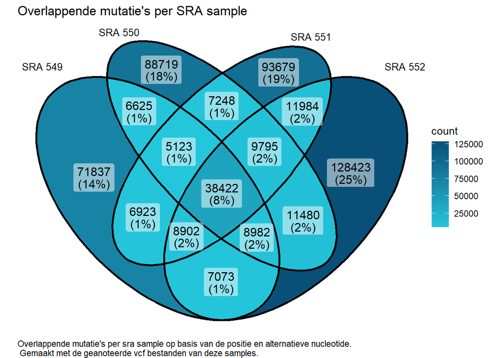

```r
new_col_549 <- paste(as.character(ssr_549_an$POS), ssr_549_an$ALT, sep = "-")
new_col_550 <- paste(as.character(ssr_550_an$POS), ssr_550_an$ALT, sep = "-")
new_col_551 <- paste(as.character(ssr_551_an$POS), ssr_551_an$ALT, sep = "-")
new_col_552 <- paste(as.character(ssr_552_an$POS), ssr_552_an$ALT, sep = "-")

ggVennDiagram(list(new_col_549,new_col_550,new_col_551,new_col_552),
              category.names = c("SRA 549", "SRA 550", "SRA 551", "SRA 552"),
              set_size = 3.5) +
  ggplot2::scale_fill_gradient(high = "#085078", low = "#24C6DC")+
  labs(title = "Overlappende mutatie's per SRA sample",
       caption = "Overlappende mutatie's per sra sample op basis van de positie en alternatieve nucleotide.\n Gemaakt met de geanoteerde vcf bestanden van deze samples.")+
  theme(plot.caption = element_text(hjust = 0))
```

Hierboven zie je de ven diagram van de overlappende mutaties per sample op basis van alternatieve nucleotide. Wat hier opvalt is dat de totale hoeveelheid gedeelde mutatie’s maar 8% geteeld is over alle mutatie’s heen, en dat alle samples op zich zelf toch wel een een significante hoeveelheid mutatie’s hebben.

# Week 6

## maandag

Het doel van vandaag is verder werken aan de ven diagram

# bibliografie

[1]Fastqc Versie 0.12 (R package v 0.1.3) https://www.bioinformatics.babraham.ac.uk/projects/fastqc/

[2]Trimmomatic Versie 0.39 http://www.usadellab.org/cms/?page=trimmomatic

[3]SRA Toolkit Versie 3.1.1 https://github.com/ncbi/sra-tools/wiki/08.-prefetch-and-fasterq-dump

[4]Seqtk Versie 1.4 https://github.com/lh3/seqtk

[5]MultiQC Versie 1.25 https://multiqc.info/

[6]BWA-mem2 Versie 2.2.1 https://github.com/bwa-mem2/bwa-mem2

[7]Freebayes versie 1.3.6-linux versie https://github.com/freebayes/freebayes

[8]Samtools versie 1.16.1 https://www.htslib.org/